# chapter6-3

## (f) Now generate a response vector Y according to the model Y = β 0 + β 7 X^7 + E, and perform best subset selection and the lasso. Discuss the results obtained.

```r
B7=8
Y2=B0+B7*(X^7)+E
XY2data=data.frame(X,Y2)
summary(XY2data)
```

```
##        X                Y2
##  Min.   : 7.851   Min.   : 14704978
##  1st Qu.: 9.437   1st Qu.: 53323063
##  Median : 9.890   Median : 74062435
##  Mean   : 9.969   Mean   : 91299650
##  3rd Qu.:10.509   3rd Qu.:113276889
##  Max.   :12.072   Max.   :298919048
```

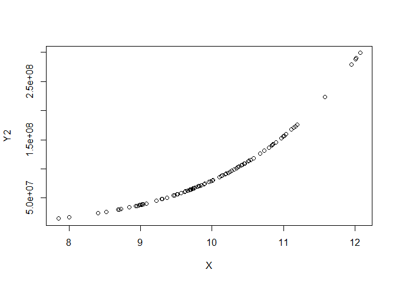

```r
plot(X,Y2)
```

```r
# best subset selection

library(leaps)

XY2regfit.full=regsubsets(Y2~poly(X,10),XY2data,nvmax = 10)
summary(XY2regfit.full)
```

```
## Subset selection object
## Call: regsubsets.formula(Y2 ~ poly(X, 10), XY2data, nvmax = 10)
## 10 Variables  (and intercept)
##               Forced in Forced out
## poly(X, 10)1      FALSE      FALSE
## poly(X, 10)2      FALSE      FALSE
## poly(X, 10)3      FALSE      FALSE
## poly(X, 10)4      FALSE      FALSE
## poly(X, 10)5      FALSE      FALSE
## poly(X, 10)6      FALSE      FALSE
## poly(X, 10)7      FALSE      FALSE
## poly(X, 10)8      FALSE      FALSE
## poly(X, 10)9      FALSE      FALSE
## poly(X, 10)10     FALSE      FALSE
## 1 subsets of each size up to 10
## Selection Algorithm: exhaustive
##           poly(X, 10)1 poly(X, 10)2 poly(X, 10)3 poly(X, 10)4 poly(X, 10)5
## 1  ( 1 )  "*"          " "          " "          " "          " "
## 2  ( 1 )  "*"          "*"          " "          " "          " "
## 3  ( 1 )  "*"          "*"          "*"          " "          " "
## 4  ( 1 )  "*"          "*"          "*"          "*"          " "
## 5  ( 1 )  "*"          "*"          "*"          "*"          "*"
## 6  ( 1 )  "*"          "*"          "*"          "*"          "*"
## 7  ( 1 )  "*"          "*"          "*"          "*"          "*"
## 8  ( 1 )  "*"          "*"          "*"          "*"          "*"
## 9  ( 1 )  "*"          "*"          "*"          "*"          "*"
## 10  ( 1 ) "*"          "*"          "*"          "*"          "*"
##           poly(X, 10)6 poly(X, 10)7 poly(X, 10)8 poly(X, 10)9
## 1  ( 1 )  " "          " "          " "          " "
## 2  ( 1 )  " "          " "          " "          " "
## 3  ( 1 )  " "          " "          " "          " "
## 4  ( 1 )  " "          " "          " "          " "
## 5  ( 1 )  " "          " "          " "          " "
## 6  ( 1 )  "*"          " "          " "          " "
## 7  ( 1 )  "*"          "*"          " "          " "
## 8  ( 1 )  "*"          "*"          " "          " "
## 9  ( 1 )  "*"          "*"          "*"          " "
## 10  ( 1 ) "*"          "*"          "*"          "*"
##           poly(X, 10)10
## 1  ( 1 )  " "
## 2  ( 1 )  " "
## 3  ( 1 )  " "
## 4  ( 1 )  " "
## 5  ( 1 )  " "
## 6  ( 1 )  " "
## 7  ( 1 )  " "
## 8  ( 1 )  "*"
## 9  ( 1 )  "*"
## 10  ( 1 ) "*"
```

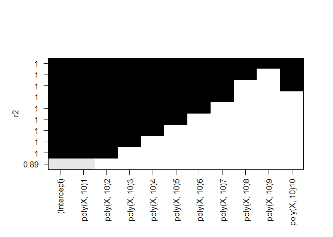

```r
plot(XY2regfit.full,scale="r2")
```

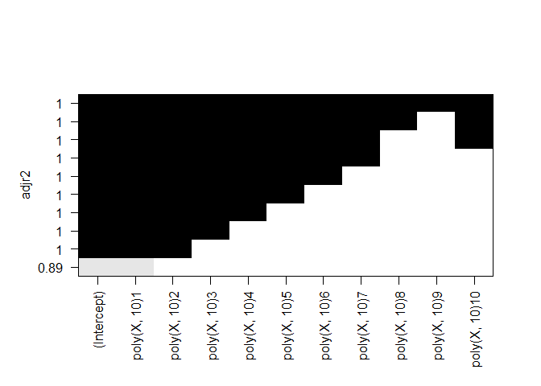

```r
plot(XY2regfit.full,scale="adjr2")
```

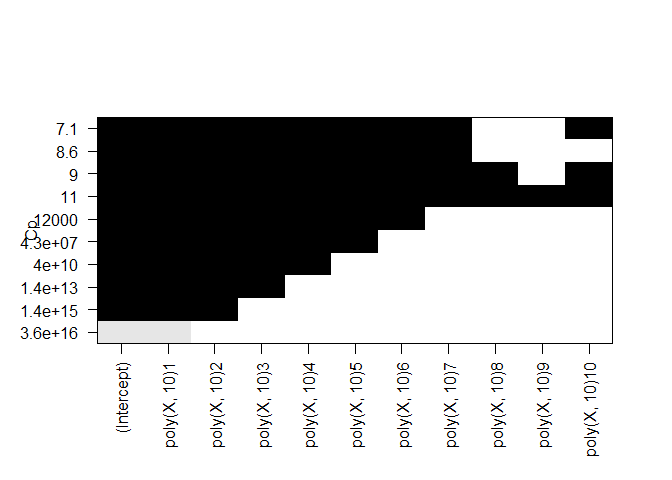

```r
plot(XY2regfit.full,scale="Cp")
```

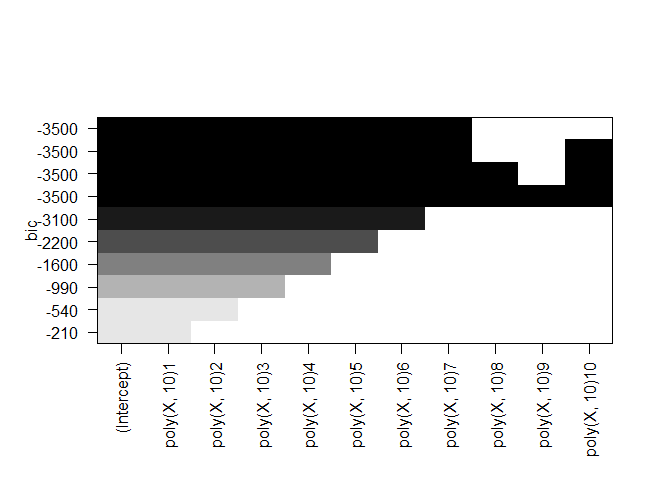

```r
plot(XY2regfit.full,scale="bic")
```

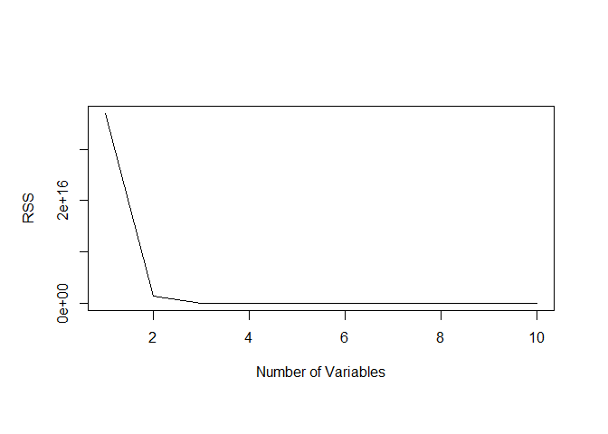

```r
XY2reg.summary=summary(XY2regfit.full)
plot(XY2reg.summary$rss,xlab="Number of Variables",ylab="RSS",type="l")
```

```r
plot(XY2reg.summary$cp,xlab="Number of Variables",ylab="Cp",type='l')
which.min(XY2reg.summary$cp)
```

```
## [1] 8
```

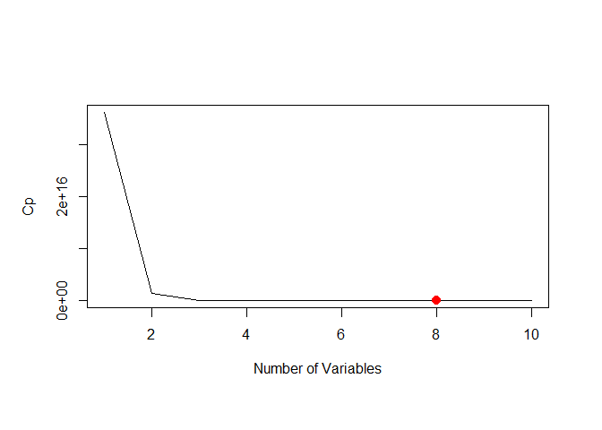

```r
points(which.min(XY2reg.summary$cp),XY2reg.summary$cp[which.min(XY2reg.summary$cp)],col="red",cex=2,pch=20)
```

```r
plot(XY2reg.summary$bic,xlab="Number of Variables",ylab="bic",type='l')
which.min(XY2reg.summary$bic)
```

```
## [1] 7
```

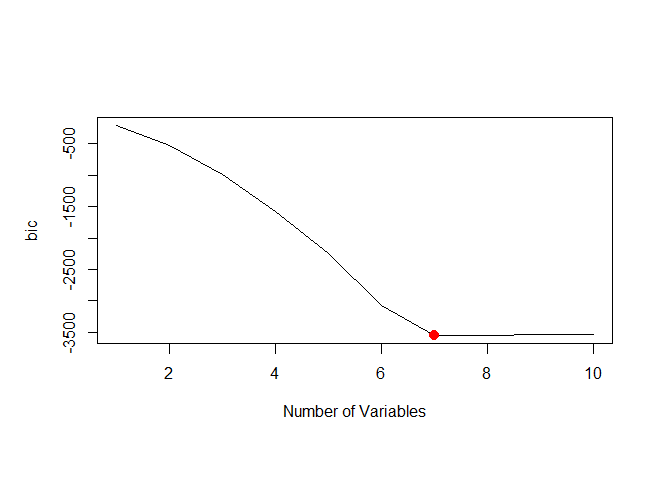

```r
points(which.min(XY2reg.summary$bic),XY2reg.summary$bic[which.min(XY2reg.summary$bic)],col="red",cex=2,pch=20)
```

```r
plot(XY2reg.summary$adjr2,xlab="Number of Variables",ylab="Adjusted RSq",type="l")
which.max(XY2reg.summary$adjr2)
```

```
## [1] 7
```

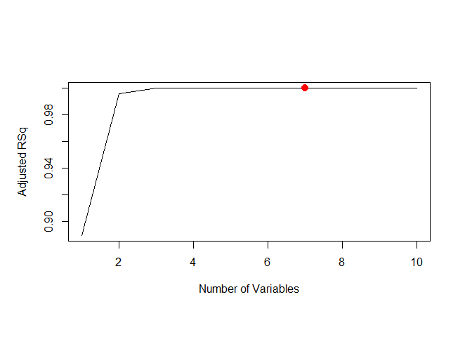

```r
points(which.max(XY2reg.summary$adjr2),XY2reg.summary$adjr2[which.max(XY2reg.summary$adjr2)], col="red",cex=2,pch=20)
```

```r
coef(XY2regfit.full,8)
```

```
##   (Intercept)  poly(X, 10)1  poly(X, 10)2  poly(X, 10)3  poly(X, 10)4
##  9.129965e+07  5.498227e+08  1.887044e+08  3.715973e+07  3.839524e+06
##  poly(X, 10)5  poly(X, 10)6  poly(X, 10)7 poly(X, 10)10
##  2.013016e+05  6.641229e+03  1.090581e+02  1.898334e+00
```

```r
coef(XY2regfit.full,7)
```

```
##  (Intercept) poly(X, 10)1 poly(X, 10)2 poly(X, 10)3 poly(X, 10)4
## 9.129965e+07 5.498227e+08 1.887044e+08 3.715973e+07 3.839524e+06
## poly(X, 10)5 poly(X, 10)6 poly(X, 10)7
## 2.013016e+05 6.641229e+03 1.090581e+02
```

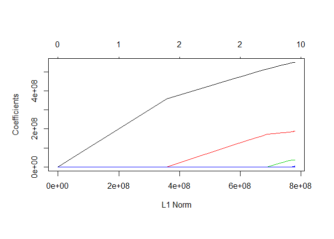

```r
# lasso
library(glmnet)

grid=10^seq(10,-2,length=100)

x=model.matrix(Y2~poly(X,10),XY2data)[,-1]
y=XY2data$Y2

set.seed(1)
train=sample(1:nrow(x), nrow(x)/2)
test=(-train)
y.test=y[test]

lasso.mod=glmnet(x[train,],y[train],alpha=1,lambda=grid)
plot(lasso.mod)
```

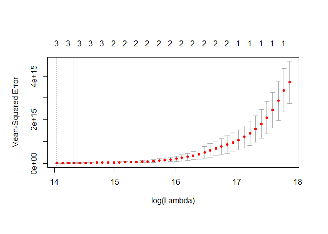

```r
set.seed(1)
cv.out=cv.glmnet(x[train,],y[train],alpha=1)
plot(cv.out)
```

```r
bestlam=cv.out$lambda.min
lasso.pred=predict(lasso.mod,s=bestlam,newx=x[test,])
mean((lasso.pred-y.test)^2)
```

```
## [1] 4.618321e+12
```

```r
out=glmnet(x,y,alpha=1,lambda=grid)
lasso.coef=predict(out,type="coefficients",s=bestlam)[1:11,]
lasso.coef
```

```
##   (Intercept)  poly(X, 10)1  poly(X, 10)2  poly(X, 10)3  poly(X, 10)4
##      91299650     537211391     176093109      24548447             0
##  poly(X, 10)5  poly(X, 10)6  poly(X, 10)7  poly(X, 10)8  poly(X, 10)9
##             0             0             0             0             0
## poly(X, 10)10
##             0
```

```r
lasso.coef[lasso.coef!=0]
```

```
##  (Intercept) poly(X, 10)1 poly(X, 10)2 poly(X, 10)3
##     91299650    537211391    176093109     24548447
```

> best subset selection

(Intercept) poly(X, 10)1 poly(X, 10)2 poly(X, 10)3 poly(X, 10)4 9.129965e+07 5.498227e+08 1.887044e+08 3.715973e+07 3.839524e+06 poly(X, 10)5 poly(X, 10)6 poly(X, 10)7 poly(X, 10)10 2.013016e+05 6.641229e+03 1.090581e+02 1.898334e+00

(Intercept) poly(X, 10)1 poly(X, 10)2 poly(X, 10)3 poly(X, 10)4 poly(X, 10)5 9.129965e+07 5.498227e+08 1.887044e+08 3.715973e+07 3.839524e+06 2.013016e+05 poly(X, 10)6 poly(X, 10)7 6.641229e+03 1.090581e+02

> lasso

(Intercept) poly(X, 10)1 poly(X, 10)2 poly(X, 10)3 91299650 537211391 176093109 24548447

# 9. In this exercise, we will predict the number of applications received using the other variables in the College data set.

## (a) Split the data set into a training set and a test set.

```r
summary(College)
```

```
##  Private        Apps           Accept          Enroll       Top10perc
##  No :212   Min.   :   81   Min.   :   72   Min.   :  35   Min.   : 1.00
##  Yes:565   1st Qu.:  776   1st Qu.:  604   1st Qu.: 242   1st Qu.:15.00
##            Median : 1558   Median : 1110   Median : 434   Median :23.00
##            Mean   : 3002   Mean   : 2019   Mean   : 780   Mean   :27.56
##            3rd Qu.: 3624   3rd Qu.: 2424   3rd Qu.: 902   3rd Qu.:35.00
##            Max.   :48094   Max.   :26330   Max.   :6392   Max.   :96.00
##    Top25perc      F.Undergrad     P.Undergrad         Outstate
##  Min.   :  9.0   Min.   :  139   Min.   :    1.0   Min.   : 2340
##  1st Qu.: 41.0   1st Qu.:  992   1st Qu.:   95.0   1st Qu.: 7320
##  Median : 54.0   Median : 1707   Median :  353.0   Median : 9990
##  Mean   : 55.8   Mean   : 3700   Mean   :  855.3   Mean   :10441
##  3rd Qu.: 69.0   3rd Qu.: 4005   3rd Qu.:  967.0   3rd Qu.:12925
##  Max.   :100.0   Max.   :31643   Max.   :21836.0   Max.   :21700
##    Room.Board       Books           Personal         PhD
##  Min.   :1780   Min.   :  96.0   Min.   : 250   Min.   :  8.00
##  1st Qu.:3597   1st Qu.: 470.0   1st Qu.: 850   1st Qu.: 62.00
##  Median :4200   Median : 500.0   Median :1200   Median : 75.00
##  Mean   :4358   Mean   : 549.4   Mean   :1341   Mean   : 72.66
##  3rd Qu.:5050   3rd Qu.: 600.0   3rd Qu.:1700   3rd Qu.: 85.00
##  Max.   :8124   Max.   :2340.0   Max.   :6800   Max.   :103.00
##     Terminal       S.F.Ratio      perc.alumni        Expend
##  Min.   : 24.0   Min.   : 2.50   Min.   : 0.00   Min.   : 3186
##  1st Qu.: 71.0   1st Qu.:11.50   1st Qu.:13.00   1st Qu.: 6751
##  Median : 82.0   Median :13.60   Median :21.00   Median : 8377
##  Mean   : 79.7   Mean   :14.09   Mean   :22.74   Mean   : 9660
##  3rd Qu.: 92.0   3rd Qu.:16.50   3rd Qu.:31.00   3rd Qu.:10830
##  Max.   :100.0   Max.   :39.80   Max.   :64.00   Max.   :56233
##    Grad.Rate
##  Min.   : 10.00
##  1st Qu.: 53.00
##  Median : 65.00
##  Mean   : 65.46
##  3rd Qu.: 78.00
##  Max.   :118.00
```

```r
dim(College)
```

```
## [1] 777  18
```

```r
#?College

x=model.matrix(Apps~.,College)[,-1]
y=College$Apps
set.seed(1)
train=sample(1:nrow(x), nrow(x)/2)
test=(-train)
y.test=y[test]

#set.seed(1)
#train=sample(1:nrow(College), nrow(College)/2)
#test=(-train)
#College.test=College[test]
```

## (b) Fit a linear model using least squares on the training set, and report the test error obtained.

```r
lm.fit=lm(y~x, subset=train)
mean((College$Apps-predict(lm.fit,College))[-train]^2)
```

```
## [1] 1108531
```

> test MSE = 1108531

## (c) Fit a ridge regression model on the training set, with λ chosen by cross-validation. Report the test error obtained.

```r
library(glmnet)
grid=10^seq(10,-2,length=100)

ridge.mod=glmnet(x,y,alpha=0,lambda=grid)

dim(coef(ridge.mod))
```

```
## [1]  18 100
```

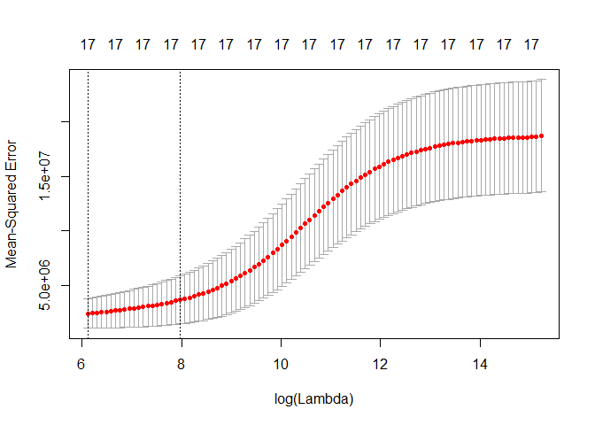

```r
ridge.mod=glmnet(x[train,],y[train],alpha=0,lambda=grid, thresh=1e-12)

set.seed(1)
cv.out=cv.glmnet(x[train,],y[train],alpha=0)
plot(cv.out)
```

```r
bestlam=cv.out$lambda.min
bestlam
```

```
## [1] 450.7435
```

```r
ridge.pred=predict(ridge.mod,s=bestlam,newx=x[test,])
mean((ridge.pred-y.test)^2)
```

```
## [1] 1037308
```

> test MSE = 1037308

## (d) Fit a lasso model on the training set, with λ chosen by cross-validation. Report the test error obtained, along with the number of non-zero coeﬃcient estimates.

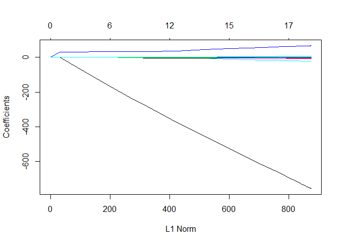

```r
# lasso
library(glmnet)

lasso.mod=glmnet(x[train,],y[train],alpha=1,lambda=grid)
plot(lasso.mod)
```

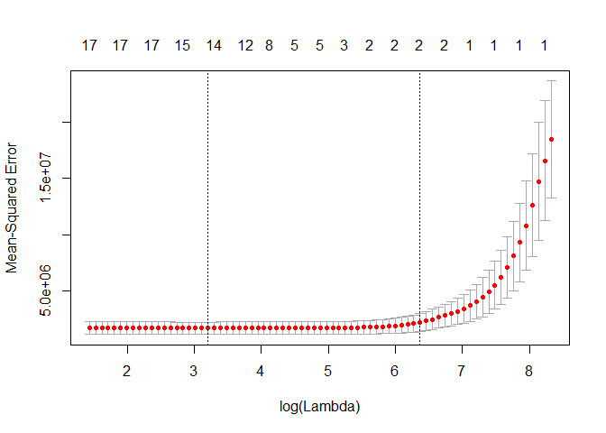

```r
set.seed(1)
cv.out=cv.glmnet(x[train,],y[train],alpha=1)
plot(cv.out)
```

```r
bestlam=cv.out$lambda.min
lasso.pred=predict(lasso.mod,s=bestlam,newx=x[test,])
mean((lasso.pred-y.test)^2)
```

```
## [1] 1032128
```

```r
out=glmnet(x,y,alpha=1,lambda=grid)
lasso.coef=predict(out,type="coefficients",s=bestlam)[1:18,]
lasso.coef
```

```
##   (Intercept)    PrivateYes        Accept        Enroll     Top10perc
## -6.321166e+02 -4.088980e+02  1.437087e+00 -1.418240e-01  3.146071e+01
##     Top25perc   F.Undergrad   P.Undergrad      Outstate    Room.Board
## -8.818529e-01  0.000000e+00  1.488050e-02 -5.348474e-02  1.206366e-01
##         Books      Personal           PhD      Terminal     S.F.Ratio
##  0.000000e+00  6.054932e-05 -5.127428e+00 -3.370371e+00  2.739664e+00
##   perc.alumni        Expend     Grad.Rate
## -1.038499e+00  6.839807e-02  4.706478e+00
```

```r
lasso.coef[lasso.coef!=0]
```

```
##   (Intercept)    PrivateYes        Accept        Enroll     Top10perc
## -6.321166e+02 -4.088980e+02  1.437087e+00 -1.418240e-01  3.146071e+01
##     Top25perc   P.Undergrad      Outstate    Room.Board      Personal
## -8.818529e-01  1.488050e-02 -5.348474e-02  1.206366e-01  6.054932e-05
##           PhD      Terminal     S.F.Ratio   perc.alumni        Expend
## -5.127428e+00 -3.370371e+00  2.739664e+00 -1.038499e+00  6.839807e-02
##     Grad.Rate
##  4.706478e+00
```

> test MSE = 1032128

# 11. We will now try to predict per capita crime rate in the Boston data set.

## (a) Try out some of the regression methods explored in this chapter, such as best subset selection, the lasso, ridge regression, and PCR. Present and discuss results for the approaches that you consider.

```r
library(MASS)
summary(Boston)
```

```
##       crim                zn             indus            chas
##  Min.   : 0.00632   Min.   :  0.00   Min.   : 0.46   Min.   :0.00000
##  1st Qu.: 0.08204   1st Qu.:  0.00   1st Qu.: 5.19   1st Qu.:0.00000
##  Median : 0.25651   Median :  0.00   Median : 9.69   Median :0.00000
##  Mean   : 3.61352   Mean   : 11.36   Mean   :11.14   Mean   :0.06917
##  3rd Qu.: 3.67708   3rd Qu.: 12.50   3rd Qu.:18.10   3rd Qu.:0.00000
##  Max.   :88.97620   Max.   :100.00   Max.   :27.74   Max.   :1.00000
##       nox               rm             age              dis
##  Min.   :0.3850   Min.   :3.561   Min.   :  2.90   Min.   : 1.130
##  1st Qu.:0.4490   1st Qu.:5.886   1st Qu.: 45.02   1st Qu.: 2.100
##  Median :0.5380   Median :6.208   Median : 77.50   Median : 3.207
##  Mean   :0.5547   Mean   :6.285   Mean   : 68.57   Mean   : 3.795
##  3rd Qu.:0.6240   3rd Qu.:6.623   3rd Qu.: 94.08   3rd Qu.: 5.188
##  Max.   :0.8710   Max.   :8.780   Max.   :100.00   Max.   :12.127
##       rad              tax           ptratio          black
##  Min.   : 1.000   Min.   :187.0   Min.   :12.60   Min.   :  0.32
##  1st Qu.: 4.000   1st Qu.:279.0   1st Qu.:17.40   1st Qu.:375.38
##  Median : 5.000   Median :330.0   Median :19.05   Median :391.44
##  Mean   : 9.549   Mean   :408.2   Mean   :18.46   Mean   :356.67
##  3rd Qu.:24.000   3rd Qu.:666.0   3rd Qu.:20.20   3rd Qu.:396.23
##  Max.   :24.000   Max.   :711.0   Max.   :22.00   Max.   :396.90
##      lstat            medv
##  Min.   : 1.73   Min.   : 5.00
##  1st Qu.: 6.95   1st Qu.:17.02
##  Median :11.36   Median :21.20
##  Mean   :12.65   Mean   :22.53
##  3rd Qu.:16.95   3rd Qu.:25.00
##  Max.   :37.97   Max.   :50.00
```

```r
# best subset selection

library(leaps)

regfit.full=regsubsets(crim~.,Boston,nvmax = 13)
summary(regfit.full)
```

```
## Subset selection object
## Call: regsubsets.formula(crim ~ ., Boston, nvmax = 13)
## 13 Variables  (and intercept)
##         Forced in Forced out
## zn          FALSE      FALSE
## indus       FALSE      FALSE
## chas        FALSE      FALSE
## nox         FALSE      FALSE
## rm          FALSE      FALSE
## age         FALSE      FALSE
## dis         FALSE      FALSE
## rad         FALSE      FALSE
## tax         FALSE      FALSE
## ptratio     FALSE      FALSE
## black       FALSE      FALSE
## lstat       FALSE      FALSE
## medv        FALSE      FALSE
## 1 subsets of each size up to 13
## Selection Algorithm: exhaustive
##           zn  indus chas nox rm  age dis rad tax ptratio black lstat medv
## 1  ( 1 )  " " " "   " "  " " " " " " " " "*" " " " "     " "   " "   " "
## 2  ( 1 )  " " " "   " "  " " " " " " " " "*" " " " "     " "   "*"   " "
## 3  ( 1 )  " " " "   " "  " " " " " " " " "*" " " " "     "*"   "*"   " "
## 4  ( 1 )  "*" " "   " "  " " " " " " "*" "*" " " " "     " "   " "   "*"
## 5  ( 1 )  "*" " "   " "  " " " " " " "*" "*" " " " "     "*"   " "   "*"
## 6  ( 1 )  "*" " "   " "  "*" " " " " "*" "*" " " " "     "*"   " "   "*"
## 7  ( 1 )  "*" " "   " "  "*" " " " " "*" "*" " " "*"     "*"   " "   "*"
## 8  ( 1 )  "*" " "   " "  "*" " " " " "*" "*" " " "*"     "*"   "*"   "*"
## 9  ( 1 )  "*" "*"   " "  "*" " " " " "*" "*" " " "*"     "*"   "*"   "*"
## 10  ( 1 ) "*" "*"   " "  "*" "*" " " "*" "*" " " "*"     "*"   "*"   "*"
## 11  ( 1 ) "*" "*"   " "  "*" "*" " " "*" "*" "*" "*"     "*"   "*"   "*"
## 12  ( 1 ) "*" "*"   "*"  "*" "*" " " "*" "*" "*" "*"     "*"   "*"   "*"
## 13  ( 1 ) "*" "*"   "*"  "*" "*" "*" "*" "*" "*" "*"     "*"   "*"   "*"
```

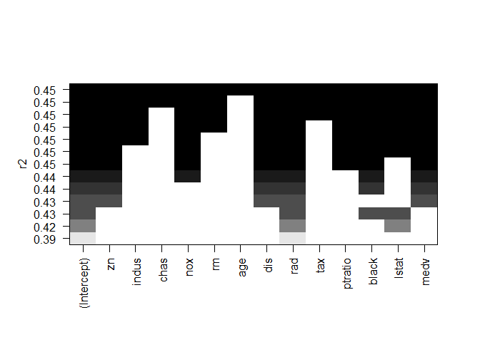

```r
plot(regfit.full,scale="r2")
```

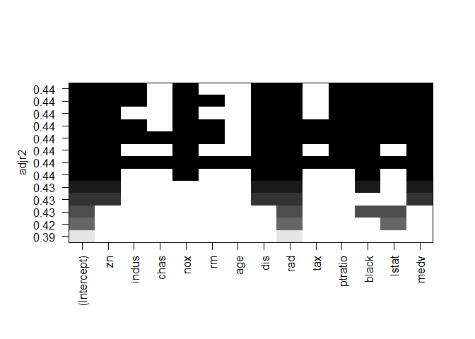

```r
plot(regfit.full,scale="adjr2")
```

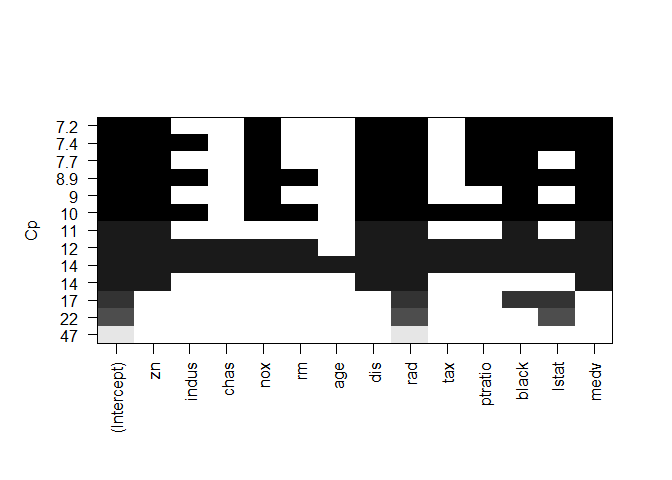

```r
plot(regfit.full,scale="Cp")
```

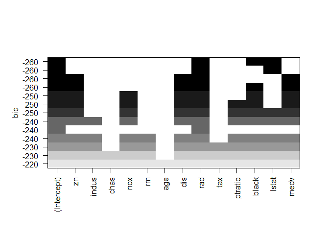

```r
plot(regfit.full,scale="bic")
```

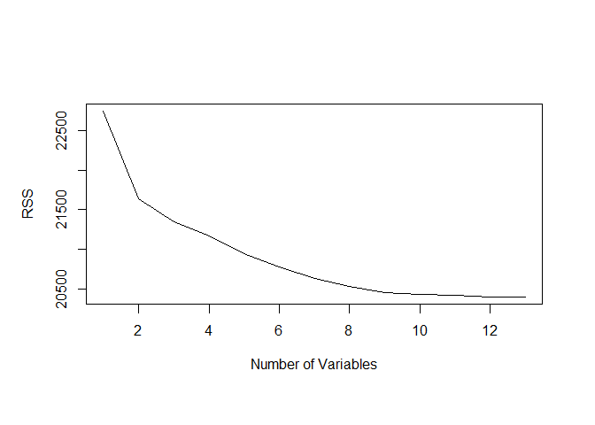

```r
reg.summary=summary(regfit.full)
plot(reg.summary$rss,xlab="Number of Variables",ylab="RSS",type="l")
```

```r
plot(reg.summary$cp,xlab="Number of Variables",ylab="Cp",type='l')
which.min(reg.summary$cp)
```

```
## [1] 8
```

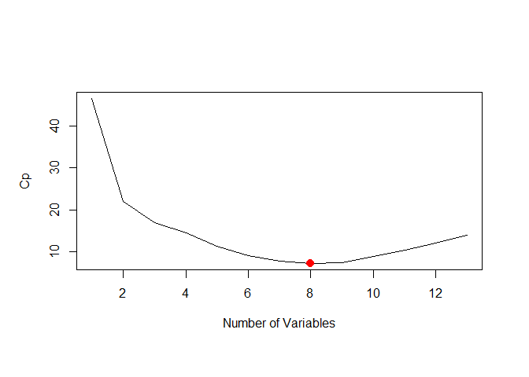

```r
points(which.min(reg.summary$cp),reg.summary$cp[which.min(reg.summary$cp)],col="red",cex=2,pch=20)
```

```r
plot(reg.summary$bic,xlab="Number of Variables",ylab="bic",type='l')
which.min(reg.summary$bic)
```

```
## [1] 3
```

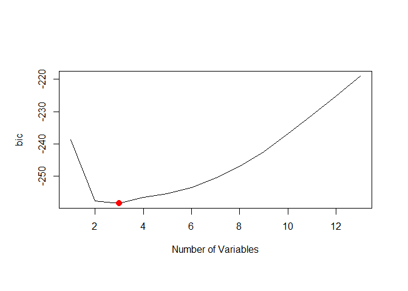

```r
points(which.min(reg.summary$bic),reg.summary$bic[which.min(reg.summary$bic)],col="red",cex=2,pch=20)
```

```r
plot(reg.summary$adjr2,xlab="Number of Variables",ylab="Adjusted RSq",type="l")
which.max(reg.summary$adjr2)
```

```
## [1] 9
```

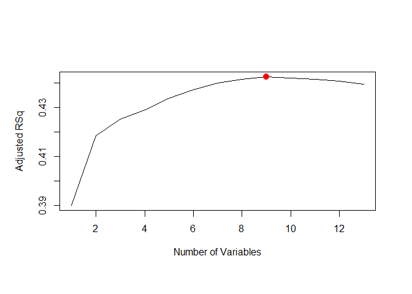

```r
points(which.max(reg.summary$adjr2),reg.summary$adjr2[which.max(reg.summary$adjr2)], col="red",cex=2,pch=20)
```

```r
coef(regfit.full,9)
```

```
##   (Intercept)            zn         indus           nox           dis
##  19.124636156   0.042788127  -0.099385948 -10.466490364  -1.002597606
##           rad       ptratio         black         lstat          medv
##   0.539503547  -0.270835584  -0.008003761   0.117805932  -0.180593877
```

```r
coef(regfit.full,8)
```

```
##   (Intercept)            zn           nox           dis           rad
##  19.683127801   0.043293393 -12.753707757  -0.918318253   0.532616533
##       ptratio         black         lstat          medv
##  -0.310540942  -0.007922426   0.110173124  -0.174207166
```

```r
coef(regfit.full,3)
```

```
##  (Intercept)          rad        black        lstat
## -0.372585457  0.488172386 -0.009471639  0.213595700
```

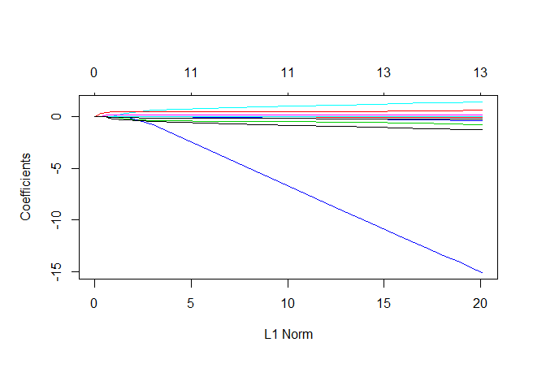

```r
# the lasso
library(glmnet)

grid=10^seq(10,-2,length=100)

x=model.matrix(crim~.,Boston)[,-1]
y=Boston$crim

set.seed(1)
train=sample(1:nrow(x), nrow(x)/2)
test=(-train)
y.test=y[test]

lasso.mod=glmnet(x[train,],y[train],alpha=1,lambda=grid)
plot(lasso.mod)
```

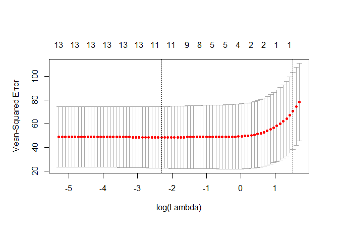

```r
set.seed(1)
cv.out=cv.glmnet(x[train,],y[train],alpha=1)
plot(cv.out)
```

```r
bestlam=cv.out$lambda.min
bestlam
```

```
## [1] 0.09979553
```

```r
lasso.pred=predict(lasso.mod,s=bestlam,newx=x[test,])
mean((lasso.pred-y.test)^2)
```

```
## [1] 38.3096
```

```r
out=glmnet(x,y,alpha=1,lambda=grid)
lasso.coef=predict(out,type="coefficients",s=bestlam)[1:11,]
lasso.coef
```

```
## (Intercept)          zn       indus        chas         nox          rm
##  9.26270091  0.03135641 -0.05102314 -0.51264890 -3.75545166  0.04132004
##         age         dis         rad         tax     ptratio
##  0.00000000 -0.60070039  0.49479389  0.00000000 -0.10750998
```

```r
lasso.coef[lasso.coef!=0]
```

```
## (Intercept)          zn       indus        chas         nox          rm
##  9.26270091  0.03135641 -0.05102314 -0.51264890 -3.75545166  0.04132004
##         dis         rad     ptratio
## -0.60070039  0.49479389 -0.10750998
```

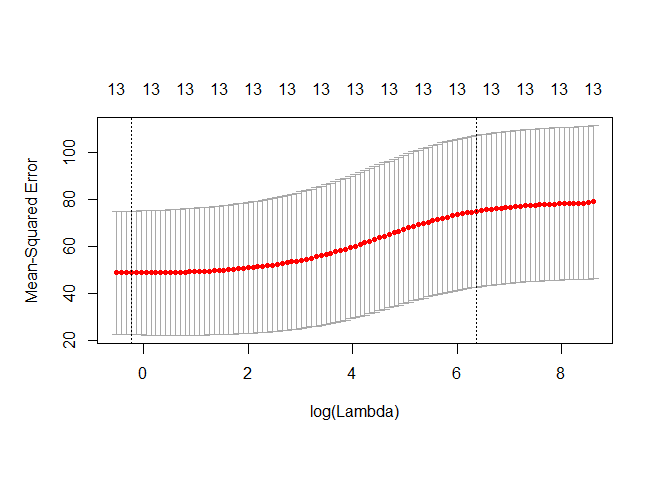

```r
# ridge regression
library(glmnet)

ridge.mod=glmnet(x[train,],y[train],alpha=0,lambda=grid, thresh=1e-12)

set.seed(1)
cv.out=cv.glmnet(x[train,],y[train],alpha=0)
plot(cv.out)
```

```r
bestlam=cv.out$lambda.min
bestlam
```

```
## [1] 0.7908625
```

```r
ridge.pred=predict(ridge.mod,s=bestlam,newx=x[test,])
mean((ridge.pred-y.test)^2)
```

```
## [1] 38.36587
```

```r
out=glmnet(x,y,alpha=0,lambda=grid)
ridge.coef=predict(out,type="coefficients",s=bestlam)[1:11,]
ridge.coef
```

```
##  (Intercept)           zn        indus         chas          nox
##  7.210622046  0.030124939 -0.076009134 -0.747210720 -4.150965154
##           rm          age          dis          rad          tax
##  0.304997445  0.002373218 -0.623135506  0.387204976  0.004545079
##      ptratio
## -0.101347676
```

> best subset selection, Cp: 8; bic: 3; Adjusted RSq: 9

(Intercept) zn indus nox dis 19.124636156 0.042788127 -0.099385948 -10.466490364 -1.002597606 rad ptratio black lstat medv 0.539503547 -0.270835584 -0.008003761 0.117805932 -0.180593877 (Intercept) zn nox dis rad 19.683127801 0.043293393 -12.753707757 -0.918318253 0.532616533 ptratio black lstat medv -0.310540942 -0.007922426 0.110173124 -0.174207166 (Intercept) rad black lstat -0.372585457 0.488172386 -0.009471639 0.213595700

> lasso: 8

(Intercept) zn indus chas nox rm 9.26270091 0.03135641 -0.05102314 -0.51264890 -3.75545166 0.04132004 dis rad ptratio -0.60070039 0.49479389 -0.10750998

> MSE = 38.3096

> ridge regression

## (b) Propose a model (or set of models) that seem to perform well on this data set, and justify your answer. Make sure that you are evaluating model performance using validation set error, cross-validation, or some other reasonable alternative, as opposed to using training error.

```r
# Choosing Among Models
# validation set approach

set.seed(1)
train=sample(c(TRUE,FALSE), nrow(Boston),rep=TRUE)
test=(!train)

regfit.best=regsubsets(crim~.,Boston[train,],nvmax = 13)
summary(regfit.best)
```

```
## Subset selection object
## Call: regsubsets.formula(crim ~ ., Boston[train, ], nvmax = 13)
## 13 Variables  (and intercept)
##         Forced in Forced out
## zn          FALSE      FALSE
## indus       FALSE      FALSE
## chas        FALSE      FALSE
## nox         FALSE      FALSE
## rm          FALSE      FALSE
## age         FALSE      FALSE
## dis         FALSE      FALSE
## rad         FALSE      FALSE
## tax         FALSE      FALSE
## ptratio     FALSE      FALSE
## black       FALSE      FALSE
## lstat       FALSE      FALSE
## medv        FALSE      FALSE
## 1 subsets of each size up to 13
## Selection Algorithm: exhaustive
##           zn  indus chas nox rm  age dis rad tax ptratio black lstat medv
## 1  ( 1 )  " " " "   " "  " " " " " " " " "*" " " " "     " "   " "   " "
## 2  ( 1 )  " " " "   " "  " " " " " " " " "*" " " " "     " "   "*"   " "
## 3  ( 1 )  " " " "   " "  " " "*" " " " " "*" " " " "     " "   " "   "*"
## 4  ( 1 )  " " " "   " "  " " "*" " " " " "*" " " " "     " "   "*"   "*"
## 5  ( 1 )  "*" " "   " "  " " "*" " " "*" "*" " " " "     " "   " "   "*"
## 6  ( 1 )  "*" " "   " "  " " "*" " " "*" "*" " " " "     " "   "*"   "*"
## 7  ( 1 )  "*" " "   " "  " " "*" " " "*" "*" " " " "     "*"   "*"   "*"
## 8  ( 1 )  "*" " "   " "  " " "*" "*" "*" "*" " " " "     "*"   "*"   "*"
## 9  ( 1 )  "*" " "   " "  " " "*" "*" "*" "*" " " "*"     "*"   "*"   "*"
## 10  ( 1 ) "*" " "   " "  "*" "*" "*" "*" "*" " " "*"     "*"   "*"   "*"
## 11  ( 1 ) "*" " "   " "  "*" "*" "*" "*" "*" "*" "*"     "*"   "*"   "*"
## 12  ( 1 ) "*" " "   "*"  "*" "*" "*" "*" "*" "*" "*"     "*"   "*"   "*"
## 13  ( 1 ) "*" "*"   "*"  "*" "*" "*" "*" "*" "*" "*"     "*"   "*"   "*"
```

```r
test.mat=model.matrix(crim~.,Boston[test,])

val.errors=rep(NA,13)
for(i in 1:13){
   coefi=coef(regfit.best,id=i)
   pred=test.mat[,names(coefi)]%*%coefi
   val.errors[i]=mean((Boston$crim[test]-pred)^2)
}

val.errors
```

```
##  [1] 58.50445 55.89099 57.93484 57.69696 56.87287 56.80141 59.49510
##  [8] 60.34830 60.42652 59.60702 59.38341 59.30440 59.36511
```

```r
which.min(val.errors)
```

```
## [1] 2
```

```r
coef(regfit.best,2)
```

```
## (Intercept)         rad       lstat
##  -3.7604819   0.4750033   0.2041807
```

```r
# best model has 2 variables

# make a predict function
predict.regsubsets=function(object,newdata,id,...){
  form=as.formula(object$call[[2]])
  mat=model.matrix(form,newdata)
  coefi=coef(object,id=id)
  xvars=names(coefi)
  mat[,xvars]%*%coefi
  }

regfit.best=regsubsets(crim~.,Boston,nvmax=13)
coef(regfit.best,2)
```

```
## (Intercept)         rad       lstat
##  -4.3814053   0.5228128   0.2372846
```

```r
# Cross validation

k=10
set.seed(1)
folds=sample(1:k,nrow(Boston),replace=TRUE)
cv.errors=matrix(NA,k,13, dimnames=list(NULL, paste(1:13)))

for(j in 1:k){
  best.fit=regsubsets(crim~.,data=Boston[folds!=j,],nvmax=13)
  for(i in 1:13){
    pred=predict.regsubsets(best.fit,Boston[folds==j,],id=i)
    cv.errors[j,i]=mean((Boston$crim[folds==j]-pred)^2)
    }
}

mean.cv.errors=apply(cv.errors,2,mean)
mean.cv.errors
```

```
##        1        2        3        4        5        6        7        8
## 43.79995 42.64344 42.98910 42.53276 42.45726 42.39477 41.76549 41.82720
##        9       10       11       12       13
## 41.15964 41.21315 41.27749 41.03457 41.06013
```

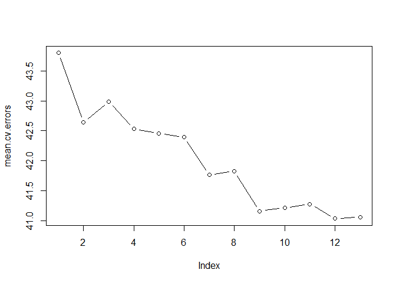

```r
par(mfrow=c(1,1))
plot(mean.cv.errors,type='b')
```

```r
reg.best=regsubsets(crim~.,data=Boston, nvmax=13)
coef(reg.best,12)
```

```
##   (Intercept)            zn         indus          chas           nox
##  16.985713928   0.044673247  -0.063848469  -0.744367726 -10.202169211
##            rm           dis           rad           tax       ptratio
##   0.439588002  -0.993556631   0.587660185  -0.003767546  -0.269948860
##         black         lstat          medv
##  -0.007518904   0.128120290  -0.198877768
```

```r
coef(reg.best,9)
```

```
##   (Intercept)            zn         indus           nox           dis
##  19.124636156   0.042788127  -0.099385948 -10.466490364  -1.002597606
##           rad       ptratio         black         lstat          medv
##   0.539503547  -0.270835584  -0.008003761   0.117805932  -0.180593877
```

> best model by validation set approach

(Intercept) rad lstat -4.3814053 0.5228128 0.2372846

> best model by Cross validation

> 12 v

(Intercept) zn indus chas nox 16.985713928 0.044673247 -0.063848469 -0.744367726 -10.202169211 rm dis rad tax ptratio 0.439588002 -0.993556631 0.587660185 -0.003767546 -0.269948860 black lstat medv -0.007518904 0.128120290 -0.198877768

> 9 v

(Intercept) zn indus nox dis 19.124636156 0.042788127 -0.099385948 -10.466490364 -1.002597606 rad ptratio black lstat medv 0.539503547 -0.270835584 -0.008003761 0.117805932 -0.180593877

## (c) Does your chosen model involve all of the features in the data set? Why or why not?

> No